# Dealing with Heterogeneity

## What about other regression assumptions?

*Do you remember the main assumptions of linear regressions?* In the section above, you focused on one of them (homogeneity of variances). Now you will address three of the others: Normality of the residuals, linearity, and independence of observations. You will **NOT** focus on the collinearity assumptions as two of the three predictors are categorical.

**Your task:**

Using the model with **untransformed data**, you will now evaluate the other assumptions of linear regressions. For this, you will use diagnostic plots and determine if the model’s residuals are normally distributed.

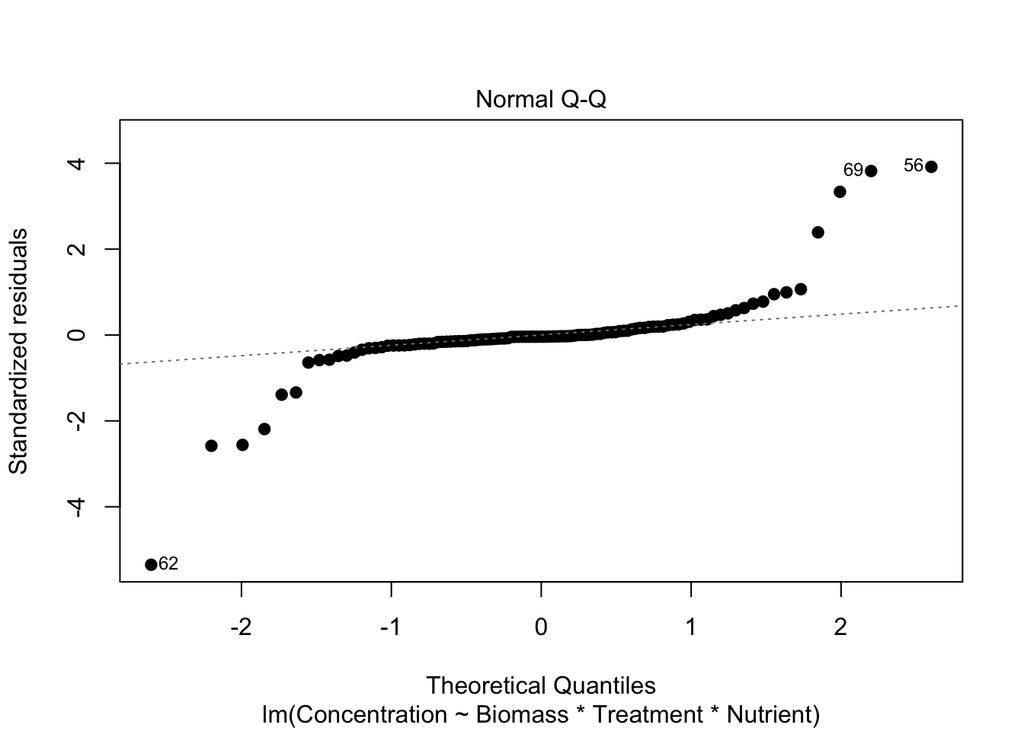

```r
# Determine if the residuals of the model are normally distributed.
# Plot the Residuals vs Fitted (look at ?plot.lm)
plot(lm.ieno, # the lm object
  which = c(2), # Which of the 4 diagnostic plots
  pch = 19, # make the Points a filled circle
  add.smooth = FALSE, # indicating if a smoother should be added
)
```

```r
# Now a statistical test for Normality
shapiro.test(lm.ieno$residuals)
```

```
##
##  Shapiro-Wilk normality test
##
## data:  lm.ieno$residuals
## W = 0.65624, p-value = 1.517e-14
```

```r
# Are the residuals of the model are normally distributed?
## No, the Normal Q-Q plot shows a large deviation from Normality. We can also see this with a Shapiro test:
```

**Your task:**

Using the model with **untransformed data**, you will now evaluate the other assumptions of linear regressions. For this, you will use diagnostic plots and establish if the relationship between `Concentration` and the predictors is linear.

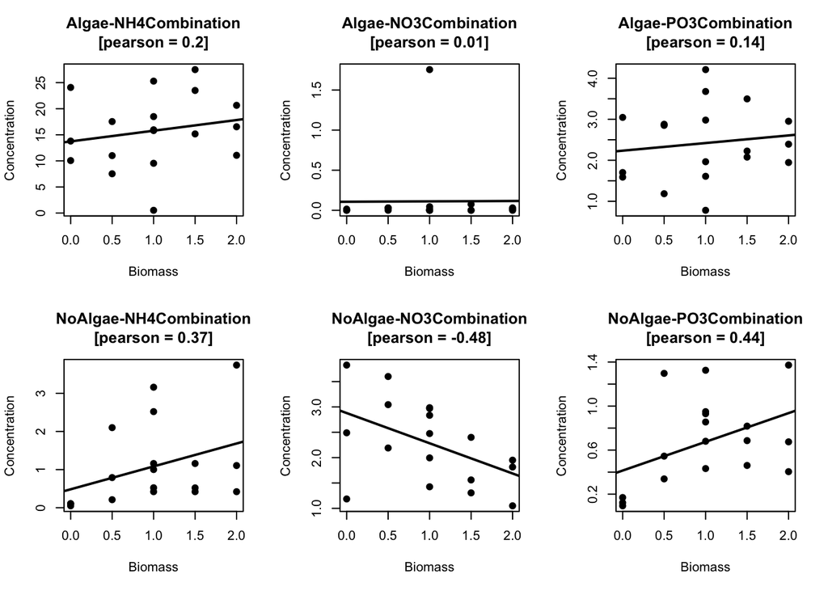

```r
# Lets' do this as a a loop
# Create a 2-row vs. 3-column plotting space
par(mfrow = c(2, 3))

# no the loops
for (Treat in c("Algae", "NoAlgae")) { # Iterate over the treatments Algae/NoAlgae
  for (Nut in c("NH4", "NO3", "PO3")) { # Iterate over the Nutrients NH4/NO3/PO3
    # Generate a temp data.frame with specific Treatment Nutrient combinations
    ieno.tmp <- ieno[c(ieno$Treatment == Treat & ieno$Nutrient == Nut), ]

    # Plot the Concentration ~ Biomass combinations
    plot(Concentration ~ Biomass, # a regression linking biomass to Concentration
      data = ieno.tmp, # Specify the name of the object where the data can be found
      pch = 19, # make the points filled circles
      main = paste0(
        Treat, "-", Nut, "Combination\n", # add a Main title
        "[pearson = ",
        round(cor(ieno.tmp$Biomass, ieno.tmp$Concentration), 2), "]"
      ) # Main figure title
    )
    # Plot a linear fit
    abline(
      reg = lm(Concentration ~ Biomass, data = ieno.tmp), # a linear model
      lwd = 2 # line widths
    )
  }
}
```

```r
# Is there is a linear relationship between `Concentration` and the predictors?
## Based on the figures, the relations appear to be linear but not very strong (based on Pearson coefficients)
```

**Your task:**

Using the model with **untransformed data**, you will now evaluate the other assumptions of linear regressions. For this, you will use diagnostic plots and assess if the observations/residuals are independent.

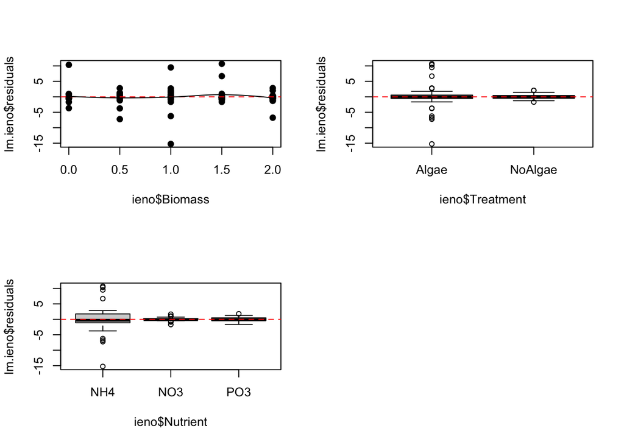

```r
# set the plotting space to a 2-row vs. 2-column plotting area
par(mfrow = c(2, 2))

# Is there a trend with Biomass?
plot(lm.ieno$residuals ~ ieno$Biomass,
  pch = 19
)
# add a horizontal line at the zero (0) level
abline(
  h = 0, # the horizontal value
  lty = 2, # the type of line
  col = "red" # the colour of the line
)
# build a smoother function
Loess.mod <- loess(lm.ieno$residuals ~ ieno$Biomass) # build a smoother function

# Plot the predictions of the smoother function smoother function
lines(
  y = predict(Loess.mod, # the smoother function
    newdata = seq(0, 2, length.out = 100)
  ), # the data used to predict
  x = seq(0, 2, length.out = 100) # the data used to predict
)

# Is there a trend with Treatment?
boxplot(lm.ieno$residuals ~ ieno$Treatment)
# add a horizontal line at the zero (0) level
abline(
  h = 0, # the horizontal value
  lty = 2, # the type of line
  col = "red" # the colour of the line
)

# Is there a trend with Nutrient?
boxplot(lm.ieno$residuals ~ ieno$Nutrient)
# add a horizontal line at the zero (0) level
abline(
  h = 0, # the horizontal value
  lty = 2, # the type of line
  col = "red" # the colour of the line
)

# Are the observations/residuals are independent?
## yes, based on the residuals predictor plots is clear that there is no trend in the residuals as a function of the predictors.
```